# Neural Networks

## Stroke Predictions

A stroke occurs when blood vessels in the brain bursts or become blocked. This can cause lasting brain damage, long-term disability, or even death. A close family member's recent bout of stroke has interested me in learning more about the causes of this disease and subsequently what can be done to prevent it. In this notebook, I will be using neural networks to predict whether a patient will become diagnosed with stroke given a set of features.

### The Data

I will be using data from a Kaggle data set:

https://www.kaggle.com/datasets/prosperchuks/health-dataset

#### Feature Columns

- sex – 1: male; 0: female
- age – patient's age (in years)
- hypertension – patient has ever had hypertension (1) or not (0)
- heart_disease – patient has ever had heart_disease(1) or not (0)
- ever_married – patient married (1) or not (0)
- work_type – patient job type: 0 - Never_worked, 1 - children, 2 - Govt_job, 3 - Self-employed, 4 - Private
- Residence_type – patient area: 1 - Urban, 0 - Rural
- avg_glucose_level – patient average blood sugar level
- bmi – Body Mass Index
- smoking_status – 1 - smokes, 0 - never smoked
- stroke – Whether the patient has stroke (1) or not (0)

```python
import pandas as pd
import numpy as np
import matplotlib.pyplot as plt
import seaborn as sns
```

```python
df = pd.read_csv('stroke_data.csv')
```

```python
df.head()
```

|  | sex | age | hypertension | heart_disease | ever_married | work_type | Residence_type | avg_glucose_level | bmi | smoking_status | stroke |
| --- | --- | --- | --- | --- | --- | --- | --- | --- | --- | --- | --- |
| 0 | 1.0 | 63.0 | 0 | 1 | 1 | 4 | 1 | 228.69 | 36.6 | 1 | 1 |
| 1 | 1.0 | 42.0 | 0 | 1 | 1 | 4 | 0 | 105.92 | 32.5 | 0 | 1 |
| 2 | 0.0 | 61.0 | 0 | 0 | 1 | 4 | 1 | 171.23 | 34.4 | 1 | 1 |
| 3 | 1.0 | 41.0 | 1 | 0 | 1 | 3 | 0 | 174.12 | 24.0 | 0 | 1 |
| 4 | 1.0 | 85.0 | 0 | 0 | 1 | 4 | 1 | 186.21 | 29.0 | 1 | 1 |

```python
df.isnull().sum()
```

```
sex                  3
age                  0
hypertension         0
heart_disease        0
ever_married         0
work_type            0
Residence_type       0
avg_glucose_level    0
bmi                  0
smoking_status       0
stroke               0
dtype: int64
```

Not bad, just 3 missing data in sex column. Lets explore that column a bit.

```python
df['sex'].unique()
```

```
array([ 1.,  0., nan])
```

Given that there are technically only 3 different answers for sex, we will treat the missing data as another category for sex. It is possible that the missing data here relates to stroke. Thus, we will create dummy variables for them.

```python
df['male'] = df['sex'].map({1:1,0:0,np.nan:0})
```

```python
df['male'].unique()
```

```
array([1, 0], dtype=int64)
```

```python
df['not-gendered'] = df['sex'].isna().map({False:0,True:1})
```

```python
df['not-gendered'].unique()
```

```
array([0, 1], dtype=int64)
```

```python
df.head()
```

|  | sex | age | hypertension | heart_disease | ever_married | work_type | Residence_type | avg_glucose_level | bmi | smoking_status | stroke | male | not-gendered |
| --- | --- | --- | --- | --- | --- | --- | --- | --- | --- | --- | --- | --- | --- |
| 0 | 1.0 | 63.0 | 0 | 1 | 1 | 4 | 1 | 228.69 | 36.6 | 1 | 1 | 1 | 0 |
| 1 | 1.0 | 42.0 | 0 | 1 | 1 | 4 | 0 | 105.92 | 32.5 | 0 | 1 | 1 | 0 |
| 2 | 0.0 | 61.0 | 0 | 0 | 1 | 4 | 1 | 171.23 | 34.4 | 1 | 1 | 0 | 0 |
| 3 | 1.0 | 41.0 | 1 | 0 | 1 | 3 | 0 | 174.12 | 24.0 | 0 | 1 | 1 | 0 |
| 4 | 1.0 | 85.0 | 0 | 0 | 1 | 4 | 1 | 186.21 | 29.0 | 1 | 1 | 1 | 0 |

```python
df[df['sex'].isna()]
```

|  | sex | age | hypertension | heart_disease | ever_married | work_type | Residence_type | avg_glucose_level | bmi | smoking_status | stroke | male | not-gendered |
| --- | --- | --- | --- | --- | --- | --- | --- | --- | --- | --- | --- | --- | --- |
| 22478 | NaN | 39.0 | 0 | 0 | 1 | 4 | 1 | 70.56 | 28.6 | 1 | 0 | 0 | 1 |
| 28908 | NaN | 36.0 | 0 | 0 | 1 | 4 | 1 | 70.56 | 28.6 | 1 | 0 | 0 | 1 |
| 35184 | NaN | 77.0 | 0 | 0 | 1 | 4 | 1 | 70.56 | 28.6 | 1 | 0 | 0 | 1 |

Now we can drop sex.

```python
df.drop('sex',axis=1,inplace=True)
```

```python
df.isnull().sum()
```

```
age                  0
hypertension         0
heart_disease        0
ever_married         0
work_type            0
Residence_type       0
avg_glucose_level    0
bmi                  0
smoking_status       0
stroke               0
male                 0
not-gendered         0
dtype: int64
```

After taking care of all missing data, it is time for some exploratory data analysis. First, let's check if stroke and non-stroke cases are balanced. If a disproportionate amount of patients do not have stroke, this can mess up our machine-learning model.

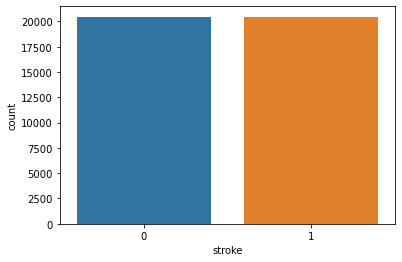

```python
sns.countplot(data=df,x='stroke')
```

Luckily, the dataset has already balanced its classes. Now we can look into what features have the highest correlation with stroke to get a general idea of what our model will do.

```python
corr = df.corr()
```

```
(10.0, 0.0)
```

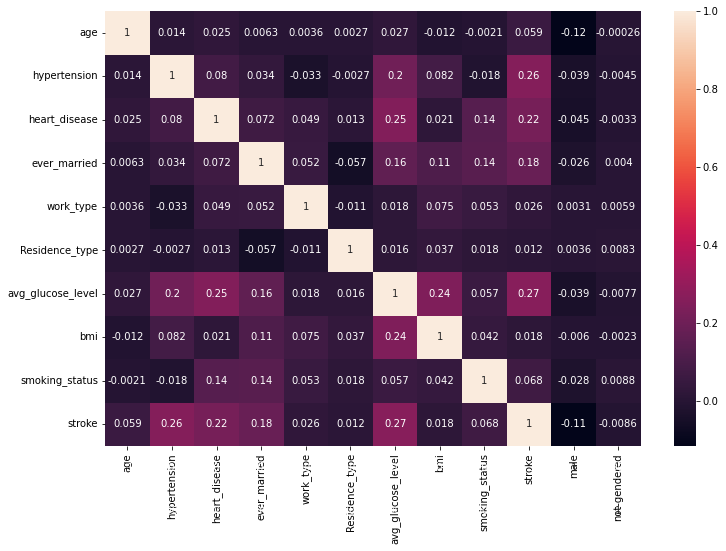

```python
plt.figure(figsize=(12,8))
sns.heatmap(corr,annot=True)
plt.ylim(10,0)
```

```python
corr['stroke'].sort_values(ascending=False)
```

```
stroke               1.000000
avg_glucose_level    0.265452
hypertension         0.257182
heart_disease        0.223930
ever_married         0.181656
smoking_status       0.068368
age                  0.058534
work_type            0.026494
bmi                  0.018326
Residence_type       0.011682
not-gendered        -0.008566
male                -0.110945
Name: stroke, dtype: float64
```

Hyptertension, heart_disease, ever_married, and avg_glucose_level seem to be the strongest correlated with stroke. Gender(or male in this case) has the strongest negative correlation with stroke. I am curious as to why ever_married and gender have significant correlation.

We will split the data into training and testing sets. Scaling/normalizing the data helps to prevent vanishing gradients.

```python
from sklearn.model_selection import train_test_split
from sklearn.preprocessing import MinMaxScaler
```

```python
X = df.drop('stroke',axis=1)
y = df['stroke']
X_train, X_test, y_train, y_test = train_test_split(X,y,test_size=0.25,random_state=101)
```

```python
scaler = MinMaxScaler()
```

```python
scaler.fit(X_train)
```

```
MinMaxScaler()
```

```python
X_train = scaler.transform(X_train)
X_test = scaler.transform(X_test)
```

Since this is a binary classification question, we will be creating a model with optimizer 'adam' and loss 'binary_crossentropy.'

```python
import tensorflow as tf
from tensorflow.keras.models import Sequential
from tensorflow.keras.layers import Dense, Activation,Dropout
```

```python
X_train.shape
```

```
(30682, 11)
```

```python
model = Sequential()

model.add(Dense(units=30,activation='relu'))
model.add(Dense(units=15,activation='relu'))
model.add(Dense(units=1,activation='sigmoid'))

model.compile(loss='binary_crossentropy', optimizer='adam')
```

We will train the model. To start off, let's choose an arbitrary epoch of 600.

```python
model.fit(x=X_train, y=y_train, epochs=600, validation_data=(X_test, y_test), verbose=1)
```

```
<keras.callbacks.History at 0x2deea0b8790>
```

```python
model_loss = pd.DataFrame(model.history.history)
```

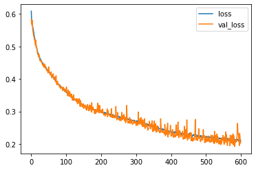

```python
model_loss.plot()
```

In the end, the loss still hovers over 0.18 which doesn't seem to be doing well. Let's try using 2 layers instead.

```python
X_train.shape
```

```
(30682, 11)
```

```python
model = Sequential()
model.add(Dense(units=1000,activation='relu'))
model.add(Dense(units=1,activation='sigmoid'))

model.compile(loss='binary_crossentropy', optimizer='adam')
```

```python
model.fit(x=X_train,
          y=y_train,
          epochs=600,
          validation_data=(X_test, y_test), verbose=1
          )
```

```
<keras.callbacks.History at 0x2deed7d3fa0>
```

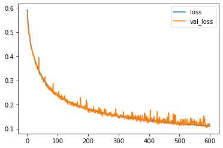

```python
model_loss = pd.DataFrame(model.history.history)
model_loss.plot()
```

```python
from tensorflow.keras.models import load_model
```

```python
model.save('thousand_model.h5')
```

That looks much better! The loss is hovering around .11 but loss and val_loss don't appear to diverge so overfitting is probably not an issue. We could do early stopping, but it does not look necessary. We will save the model for now.

Let's add dropout layers to see if they improve loss.

```python
from tensorflow.keras.layers import Dropout
```

```python
model = Sequential()
model.add(Dense(units=1000,activation='relu'))
model.add(Dropout(0.6))

model.add(Dense(units=1,activation='sigmoid'))
model.compile(loss='binary_crossentropy', optimizer='adam')
```

```python
model.fit(x=X_train,
          y=y_train,
          epochs=50,
          validation_data=(X_test, y_test), verbose=1
         )
```

```
<keras.callbacks.History at 0x2deef961a60>
```

```python
model = Sequential()
model.add(Dense(units=1000,activation='relu'))
model.add(Dropout(0.2))

model.add(Dense(units=1,activation='sigmoid'))
model.compile(loss='binary_crossentropy', optimizer='adam')
```

```python
model.fit(x=X_train,
          y=y_train,
          epochs=50,
          validation_data=(X_test, y_test), verbose=1
         )
```

```
<keras.callbacks.History at 0x2deefc4f940>
```

Unfortunately, dropout layers don't seem to help as they have consistently worse loss rates. In hindset, this was probably obvious given that dropout layers serve to prevent overfitting and that wasn't an issue in the original model. Anyways, we will stick to the original model.

```python
from sklearn.metrics import classification_report,confusion_matrix
from tensorflow import keras
```

```python
model_best = keras.models.load_model('thousand_model.h5')
```

```python
predictions = (model_best.predict(X_test) > 0.5).astype("int32")
```

```python
print(classification_report(y_test,predictions))
```

```
              precision    recall  f1-score   support

           0       0.96      0.94      0.95      5028
           1       0.95      0.96      0.96      5200

    accuracy                           0.95     10228
   macro avg       0.95      0.95      0.95     10228
weighted avg       0.95      0.95      0.95     10228
```

```python
print(confusion_matrix(y_test,predictions))
```

```
[[4740  288]
 [ 182 5018]]
```

According to our classification_report and confusion_matrix, we have achieved around 95% accuracy. That's pretty good! Let's use this to play around with some feature values.

```python
dct = {'age':80.,'hypertension':0,'heart_disease':0,'ever_married':1,'work_type':1,'Residence_type':1,'avg_glucose_level':200,'bmi':30,'smoking_status':0,'male':0,'not-gendered':0}
new_patient = pd.Series(dct)
new_patient = scaler.transform([new_patient])
model_best.predict(new_patient)
```

```
array([[4.149022e-26]], dtype=float32)
```

```python
dct = {'age':90.,'hypertension':1,'heart_disease':0,'ever_married':1,'work_type':0,'Residence_type':1,'avg_glucose_level':220,'bmi':30,'smoking_status':0,'male':0,'not-gendered':0}
new_patient = pd.Series(dct)
new_patient = scaler.transform([new_patient])
model_best.predict(new_patient)
```

```
array([[0.]], dtype=float32)
```

```python
dct = {'age':30.,'hypertension':0,'heart_disease':1,'ever_married':1,'work_type':1,'Residence_type':1,'avg_glucose_level':300,'bmi':30,'smoking_status':1,'male':0,'not-gendered':0}
new_patient = pd.Series(dct)
new_patient = scaler.transform([new_patient])
model_best.predict(new_patient)
```

```
array([[0.9991387]], dtype=float32)
```

```python
dct = {'age':80.,'hypertension':1,'heart_disease':1,'ever_married':1,'work_type':1,'Residence_type':1,'avg_glucose_level':215,'bmi':30,'smoking_status':1,'male':0,'not-gendered':0}
new_patient = pd.Series(dct)
new_patient = scaler.transform([new_patient])
model_best.predict(new_patient)
```

```
array([[0.9998926]], dtype=float32)
```

```python
dct = {'age':80.,'hypertension':1,'heart_disease':1,'ever_married':1,'work_type':1,'Residence_type':1,'avg_glucose_level':216,'bmi':30,'smoking_status':1,'male':0,'not-gendered':0}
new_patient = pd.Series(dct)
new_patient = scaler.transform([new_patient])
model_best.predict(new_patient)
```

```
array([[0.9999396]], dtype=float32)
```

```python
dct = {'age':20.,'hypertension':1,'heart_disease':0,'ever_married':1,'work_type':3,'Residence_type':1,'avg_glucose_level':200,'bmi':30,'smoking_status':1,'male':0,'not-gendered':0}
new_patient = pd.Series(dct)
new_patient = scaler.transform([new_patient])
model_best.predict(new_patient)
```

```
array([[0.06560843]], dtype=float32)
```

```python
dct = {'age':25.,'hypertension':0,'heart_disease':0,'ever_married':1,'work_type':3,'Residence_type':0,'avg_glucose_level':120,'bmi':20,'smoking_status':0,'male':0,'not-gendered':0}
new_patient = pd.Series(dct)
new_patient = scaler.transform([new_patient])
model_best.predict(new_patient)
```

```
array([[0.00106023]], dtype=float32)
```

```python
dct = {'age':95.,'hypertension':0,'heart_disease':0,'ever_married':1,'work_type':3,'Residence_type':0,'avg_glucose_level':120,'bmi':20,'smoking_status':0,'male':0,'not-gendered':0}
new_patient = pd.Series(dct)
new_patient = scaler.transform([new_patient])
model_best.predict(new_patient)
```

```
array([[0.2418017]], dtype=float32)
```

It is interesting to see that no one single factor dominates when the determination for stroke but rather a set of factors. Some of them carry more weight than others, such as hypertension and heart_disease, while others appear to not affect the outcome at all unless other values are just right.

However, I thought age would be a larger factor than presented here. Let's see the distribution for age.

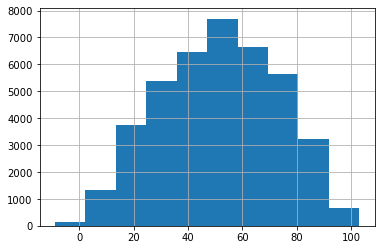

```python
df['age'].hist()
```

### Conclusion

I initially started this project hoping to enlighten myself on the causes of stroke. I really expected age to play a larger part than it did in the dataset. Perhaps my initial assumptions were wrong, or maybe that the data deliberately collected stroke and nonstroke cases from a wide range of ages. Or that stroke only starts appearing frequently at a very large age and the age range here does not capture it. Nevertheless, hyptertension, heart_disease, ever_married, avg_glucose_level, and sex are significant risk factors for stroke.

### Outside Research

Other online sources, such [CDC](https://www.cdc.gov/stroke/index.htm), corroborate these findings. Hypertension, or high blood pressure, serves as a main risk factor for stroke. Women are at higher risk for strokes because they tend to live longer than men. Obesity and diabetes, both related to blood glucose levels and bmi, are other risk factors. ever_married was a feature that I was initially surprised had moderate correlation, but makes sense if we consider that stress causes high blood pressure. Thus, frequent exercise, healthier eating habits, and calming activities are good ways for reducing the risk of a stroke.

Overall, I am proud that my model did well. These results are intriguing and may be a starting point for further research.

### References

https://www.udemy.com/course/python-for-data-science-and-machine-learning-bootcamp/

https://towardsdatascience.com/how-to-drop-rows-in-pandas-dataframes-with-nan-values-in-certain-columns-7613ad1a7f25

https://www.cdc.gov/stroke/index.htm